# Homework 9 [Neural Network and Deep Learning]

## 111550196 狄豪飛

### Dataset: Fashion-MNIST: This is a more challenging alternative to the MNIST dataset, with images of fashion items. It offers higher complexity than MNIST and is good for classification problems.

```python
import tensorflow as tf
import matplotlib.pyplot as plt
import numpy as np
```

Explore Dataset: Understand the shape, size, and nature of the data. This includes exploring the number of samples, the dimensions of each image, and the number of classes. You can also visualize some of the images to get a sense of what you're working with:

```
Training set shape: (60000, 28, 28)
Number of training labels: 60000
Test set shape: (10000, 28, 28)
Number of test labels: 10000
```

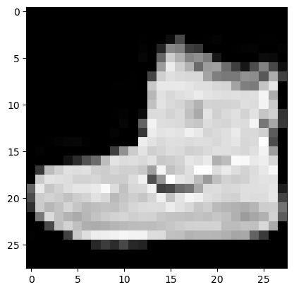

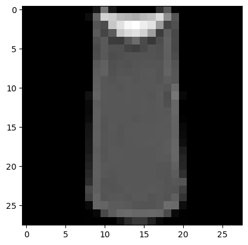

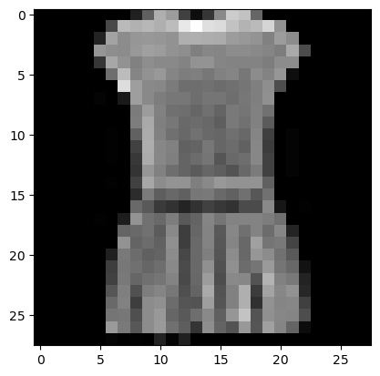

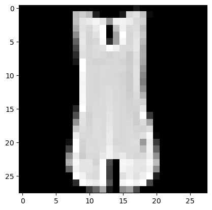

```python
from tensorflow.keras.datasets import fashion_mnist
(train_images, train_labels), (test_images, test_labels) = fashion_mnist.load_data()

print("Training set shape:", train_images.shape)
print("Number of training labels:", len(train_labels))
print("Test set shape:", test_images.shape)
print("Number of test labels:", len(test_labels))

# Visualize the first image in the training set
plt.imshow(train_images[0], cmap='gray')
plt.show()
plt.imshow(train_images[2], cmap='gray')
plt.show()
plt.imshow(train_images[3], cmap='gray')
plt.show()
plt.imshow(train_images[4], cmap='gray')
plt.show()
```

### Objective: Prepare the dataset for input into the neural network.

#### Actions:

- Normalize Images: Scale the image pixel values to a range of 0 to 1 for more effective training. Since pixel values range from 0 to 255, dividing by 255 achieves this normalization.
- Reshape Images (if using CNNs): If you're using a Convolutional Neural Network (CNN), you'll need to reshape the images to include a channel dimension. Since Fashion-MNIST images are grayscale, the channel dimension is 1.

```python
train_images = train_images / 255.0
test_images = test_images / 255.0
train_images = train_images.reshape((-1, 28, 28, 1))
test_images = test_images.reshape((-1, 28, 28, 1))
```

#### Design Neural Network Architecture

Create a model suitable for classifying Fashion-MNIST images.

Actions:

- Choose Model Type: For Fashion-MNIST, a CNN is generally effective.
- Define the Architecture:

```python
from tensorflow.keras import layers, models

model = models.Sequential([
    layers.Conv2D(32, (3, 3), activation='relu', input_shape=(28, 28, 1)),
    layers.MaxPooling2D((2, 2)),
    layers.Conv2D(64, (3, 3), activation='relu'),
    layers.MaxPooling2D(2, 2),
    layers.Flatten(),
    layers.Dense(64, activation='relu'),
    layers.Dense(10, activation='softmax')
])
```

[output not shown]

#### Compile the Model

Prepare the model for training by setting up the optimizer, loss function, and metrics.

- Actions:
- Choose an Optimizer: Common choices include Adam, SGD, etc. Adam is often preferred for its effectiveness in variousscenarios.
- Set the Loss Function: For a classification problem like Fashion-MNIST, 'sparse_categorical_crossentropy' is suitable when labels are integers.
- Select Metrics for Evaluation: Accuracy is a common metric for classification problems.
- Compile the Model: Bring together the optimizer, loss function, and metrics.

```python
optimizer = 'adam'
loss = 'sparse_categorical_crossentropy'
metrics = ['accuracy']
model.compile(optimizer=optimizer, loss=loss, metrics=metrics)
```

```
WARNING:tensorflow:From C:\Users\georg\anaconda3\Lib\site-packages\keras\src\optimizers\__init__.py:309: The name tf.train.Optimizer is deprecated. Please use tf.compat.v1.train.Optimizer instead.
```

#### Objective: Fit the model to the training data.

Use the model.fit method, specifying training data, number of epochs, and optionally, validation data.

```python
epochs = 10
history = model.fit(train_images, train_labels, epochs=epochs, validation_data=(test_images, test_labels))
```

[output not shown]

```python
test_loss, test_acc = model.evaluate(test_images, test_labels, verbose=2)
print(f"Test accuracy: {test_acc}, Test loss: {test_loss}")
```

```
313/313 - 1s - loss: 0.2760 - accuracy: 0.9068 - 1s/epoch - 4ms/step
Test accuracy: 0.9067999720573425, Test loss: 0.27601516246795654
```

### Evaluate the Model

Assess the performance of the model using the test dataset.

Use the model.evaluate method with the test dataset to get the loss and accuracy.

```python
from tensorflow.keras.optimizers import Adam

# Experiment with different learning rates
learning_rate = 0.001  # Try different values like 0.01, 0.0001, etc.
optimizer = Adam(learning_rate=learning_rate)

model.compile(optimizer=optimizer, loss=loss, metrics=metrics)
```

#### Visualize Results

Graphically represent the training process and outcomes. Plot Training and Validation Accuracy and Loss: Use Matplotlib to plot the history of accuracy and loss during training.

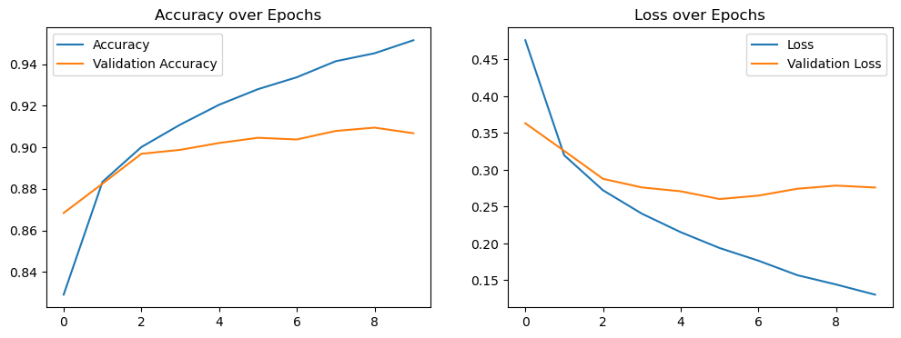

```python
plt.figure(figsize=(12, 4))
plt.subplot(1, 2, 1)
plt.plot(history.history['accuracy'], label='Accuracy')
plt.plot(history.history['val_accuracy'], label='Validation Accuracy')
plt.legend()
plt.title('Accuracy over Epochs')

plt.subplot(1, 2, 2)
plt.plot(history.history['loss'], label='Loss')
plt.plot(history.history['val_loss'], label='Validation Loss')
plt.legend()
plt.title('Loss over Epochs')

plt.show()
```

### t-SNE Visualization

Visualize the Fashion-MNIST dataset in two dimensions to understand the distribution and separability of the different classes.

```python
import numpy as np
from tensorflow.keras.datasets import fashion_mnist

# Load the Fashion-MNIST dataset
(train_images, train_labels), _ = fashion_mnist.load_data()

# Preprocess the data for t-SNE
# Select a subset of the data for manageability. For example, 3000 samples.
num_samples = 3000
indices = np.random.choice(range(len(train_images)), num_samples, replace=False)

# Flatten the images for t-SNE
X_subset = train_images[indices].reshape(num_samples, -1)
y_subset = train_labels[indices]

# Display the shapes as confirmation
print(X_subset.shape, y_subset.shape)
```

```
(3000, 784) (3000,)
```

```python
from sklearn.manifold import TSNE

# Initialize t-SNE
tsne = TSNE(n_components=2, verbose=1, perplexity=40, n_iter=300)
tsne_results = tsne.fit_transform(X_subset)
```

```
[t-SNE] Computing 121 nearest neighbors...
[t-SNE] Indexed 3000 samples in 0.002s...
[t-SNE] Computed neighbors for 3000 samples in 0.521s...
[t-SNE] Computed conditional probabilities for sample 1000 / 3000
[t-SNE] Computed conditional probabilities for sample 2000 / 3000
[t-SNE] Computed conditional probabilities for sample 3000 / 3000
[t-SNE] Mean sigma: 541.057928
[t-SNE] KL divergence after 250 iterations with early exaggeration: 67.184975
[t-SNE] KL divergence after 300 iterations: 1.655817
```

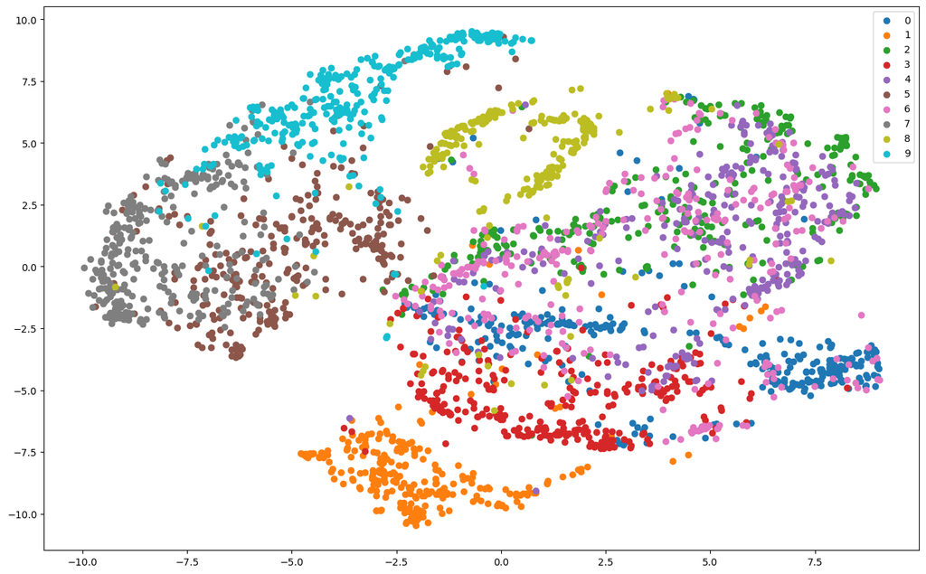

```python
import matplotlib.pyplot as plt

# Plot the t-SNE result
plt.figure(figsize=(16,10))
for class_id in range(10):
    indices = y_subset == class_id
    plt.scatter(tsne_results[indices, 0], tsne_results[indices, 1], label=class_id)

plt.legend()
plt.show()
```

Conclusions

Class Overlaps: There are areas where different colors (representing different classes) seem to be overlapping or intermingled. This overlap indicates that certain fashion items share similar features and are harder to distinguish. For example, if dark blue and light blue points are overlapping, it may indicate that those two particular classes of fashion items are similar to each other.

Separability: Some colors form distinct clusters without much intrusion from other classes, indicating good separability for those classes. A neural network should be able to classify these with higher accuracy.

Dense Regions: There are dense regions where multiple classes are present. These "borderline" areas might be challenging for the model and could benefit from more complex features or models that can capture more subtle differences.